# Er det høyde som bestemmer inntekt?

# Kort innledning

Vi vil i denne oppgaven bruke datasettet *heights*[^1] for å undersøke riktigheten av påstanden om at høyde bestemmer inntekt. Undersøkelsen vil bli gjort gjennom analyser av ulike variabler og ved regresjonsanalyser. Resultatene vil bli fremstilt i ulike modeller, før vi vil avslutte med en konklusjon av spørsmålet “er det høyde som bestemmer inntekt?”

# Litteraturgjennomgang

Judge and Cable (2004a) hevder at høyde kan skape fordeler i en rekke viktige aspekter i både liv og i karrière. Gjennom deres evalueringer med faktorene kjønn, vekt og alder legger de frem en teoretisk model av forholdet mellom høyde of inntekt. Modellen forfatterne fremlegger viser blant annet at høyde er relatert til både utførelse og selvtillit. De fremlegger videre at høyde i relasjon med inntekt eller «karriéresuksess» viste en større relasjon for menn enn for kvinner. Siste del av forskningen utført av forfatterne, fremlegger at det foreligger en tydelig sammenheng mellom høyde og inntekt - hvor de tidligere nevnte faktorene kjønn, vekt og alder er hensyntatt. Eli Kvisvik (2008a) hevder også i sin statistiske analyse fra 2008 at det eksisterer en sammenheng mellom nettopp høyde og inntekt. Hun uttrykker videre at «den høyeste fjerdedelen av den amerikanske befolkningen tjener 9-10% mer enn den laveste fjerdedelen (…)», hvor forskere begrunner dette med andre psykologiske årsaker som Judge and Cable (2004b) også referer til, nemlig selvtillit (Eli Kvisvik 2008b).

Ved å bruke både datasettet *heights* og gjennom argumentene Eli Kvisvik (2008a) og Judge and Cable (2004b) legger til grunn, vil vi teste påstandene gjennom statistiske tester som utføres videre i oppgaven. Ved bruk av datasettet og dets variabler vil vi kunne se flere aspekter relatert til høyde og inntekt hvor variablene vekt, kjønn, alder og utdannelse også vil være inkludert. Konklusjonen av oppgaven vil være basert på utfallet av de framlagte data, hvor vi naturligvis vil se om våre resultater støtter resultatene fra Judge and Cable (2004b) og Eli Kvisvik (2008a).

```r
hoyde <- heights
```

# Beskrivende statestikk

Datasettet *Heights* som har fått navnet *hoyde* består opprinnelig av åtte variabler og 7006 observasjoner. Basert på disse variablene og observasjonene skal det være mulig å konkludere om ens inntekt bestemmes av høyde. Variablene som er inkludert i datasettet er:

- Income - Basert på årlig inntekt, der topp to prosent er representert av gjennomsnittelig verdi av de to prosentene.
- Height - Høyden til subjektene som har deltatt målt i inch.
- Weight - Vekten til subjektene som har deltatt målt i pounds.
- Age - Alderen til subjektene som har deltatt er mellom 47 og 56.
- Martial - Subjektenes sivilstatus, om der gift eller skilt.
- Sex - Subjektenes kjønn, mann eller kvinne.
- Education - Subjektenes år med utdanning.
- Afqt - Subjektenes poengsum i prosent på ‘Armed Forces Qualification Test’

# EDA

## Histogram av variabelen *income*

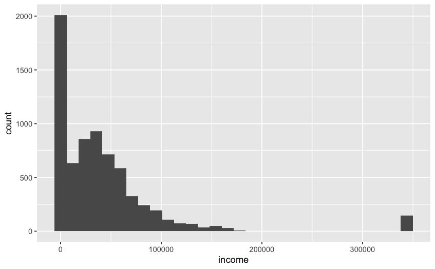

```r
ggplot(data = hoyde, aes(income)) +
  # satt inn bins=30 for å slippe warning
  geom_histogram(bins=30)
```

## Histogram av *income* fordelt på kjønn

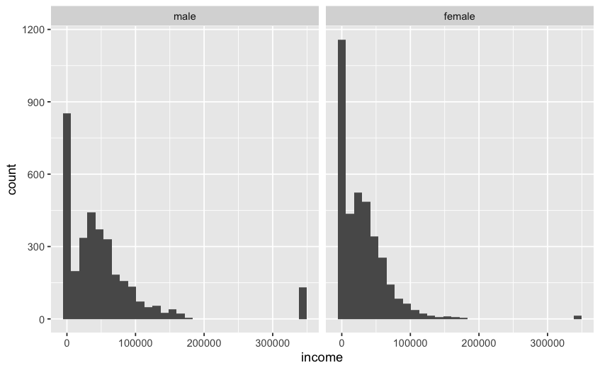

```r
# For gjort å lage facet på kjønn
ggplot(data = hoyde, aes(income)) +
  facet_wrap(~sex) +
  geom_histogram(bins=30)
```